# [Session 1: Introduction to R](https://github.com/eScienceWinterSchool/RRStudioSession)

### Prof. José Manuel Magallanes, PhD

- Associate Professor, Departamento de Ciencias Sociales, Pontificia Universidad Católica del Perú, jmagallanes@pucp.edu.pe
- Visiting Associate Professor, Evans School of Public Policy and Governance / Senior Data Science Fellow, eScience Institute, University of Washington, magajm@uw.edu

## Part A: Data Structures in R

We are going to talk about 3 data structures in R:

1. Lists.
2. Vectors.
3. Data Frame.

**Lists** and **vectors** are simple structures; a **data frame** is a more complex one (built from the simple ones).

## List

Lists are containers of values. The values can be of any kind (numbers or non-numbers), and even other containers (simple or complex). If we have an spreadsheet as a reference, a row is a ‘natural’ list.

```r
DetailStudent=list(fullName="Fred Meyers",
                   age=40,
                   female=FALSE)
```

The *object* ‘DetailStudent’ serves to store *temporarily* the list in the computer. To name a list, use combinations of letters and numbers (never start with a number) in a meaningful way. Typing the name of the object ‘DetailStudent’, now a list, will give you all the contents you saved in there:

```r
DetailStudent
```

```
## $fullName
## [1] "Fred Meyers"
##
## $age
## [1] 40
##
## $female
## [1] FALSE
```

Each of the elements in the list, in this case, holds a different type:

- *FullName* holds characters
- *age* holds a number
- *female* holds a logical (Boolean) value.

You can access individual elements like this:

```r
DetailStudent[[1]]
```

```
## [1] "Fred Meyers"
```

```r
# or
DetailStudent[['fullName']]
```

```
## [1] "Fred Meyers"
```

```r
# or
DetailStudent$fullName
```

```
## [1] "Fred Meyers"
```

You can alter the list using:

```r
DetailStudent$fullName='Alfred Mayer'
# Then:
DetailStudent
```

```
## $fullName
## [1] "Alfred Mayer"
##
## $age
## [1] 40
##
## $female
## [1] FALSE
```

You can add an element like this:

```r
DetailStudent$city='Seattle'

# show:
DetailStudent
```

```
## $fullName
## [1] "Alfred Mayer"
##
## $age
## [1] 40
##
## $female
## [1] FALSE
##
## $city
## [1] "Seattle"
```

And destroy it by **NULL**ing it, like this:

```r
DetailStudent$city=NULL # do you like: DetailStudent[[4]]=NULL
```

Go to section beginning

## Vectors

Vectors are also containers of values. The values should be of **only one type** (**R** may alter it silently, otherwise). If we have an spreadsheet as a reference, a column can be a natural vector.

```r
names=c("Fred Meyers","Sarah Jones", "Lou Ferrigno","Sky Turner")
ages=c(40,35, 60,77)
female=c(F,T,T,T)
```

Each *object* is holding temporarily a vector. Use combinations of letters and numbers (never start with a number) in a meaningful way to name a vector. When typing the name of the object you will get all the contents:

```r
names
```

```
## [1] "Fred Meyers"  "Sarah Jones"  "Lou Ferrigno" "Sky Turner"
```

```r
ages
```

```
## [1] 40 35 60 77
```

```r
female
```

```
## [1] FALSE  TRUE  TRUE  TRUE
```

Each vector is composed of elements with the same type. If you want to access individual elements, you can write:

```r
names[1]
```

```
## [1] "Fred Meyers"
```

```r
# or
ages[1]
```

```
## [1] 40
```

```r
# or
female[1]
```

```
## [1] FALSE
```

You can alter the list using:

```r
names[1]='Alfred Mayer'
# Then:
names[1]
```

```
## [1] "Alfred Mayer"
```

You can add an element to a vector like this:

```r
elements=c(1,2,3)
elements=c(elements,40)
elements
```

```
## [1]  1  2  3 40
```

You can NOT delete it with NULL:

```r
#elements[4]=NULL
```

Just do this:

```r
elements=elements[-4] # vector shrinks
elements
```

```
## [1] 1 2 3
```

Another important operation is to get rid of repeated values:

```r
weekdays=c('M','T','W','Th','S','Su','Su')
weekdays
```

```
## [1] "M"  "T"  "W"  "Th" "S"  "Su" "Su"
```

Then, use the function *unique*:

```r
unique(weekdays)
```

```
## [1] "M"  "T"  "W"  "Th" "S"  "Su"
```

Vector elements can have ‘names’, but their contents still need to be homogeneous:

```r
newAges=c("Sam"=50, "Paul"=30, "Name"="Jim")
newAges
```

```
##   Sam  Paul  Name
##  "50"  "30" "Jim"
```

As you saw above, the presence of “Jim” as an element, *coerced* the other values to *characters* (the *numbers* are now *text*, the symbol **’’** is used to show that). Eliminating that value will give an appropriate vector:

```r
newAgesGood=c("Sam"=50, "Paul"=30)
newAgesGood
```

```
##  Sam Paul
##   50   30
```

Go to section beginning

## Data Frames

Data frames are more complex containers of values. The most common analogy is a data table like the ones in a **spreadsheet**:

```r
# VECTORS
names=c("Qing", "Françoise", "Raúl", "Bjork")
ages=c(32,33,28,30)
country=c("China", "Senegal", "Spain", "Norway")
education=c("Bach", "Bach", "Master", "PhD")
```

Then, we can create a data frame:

```r
#DF as a "List" of vectors:
students=list('names'=names,'ages'=ages,'country'=country,'education'=education)
students
```

```
## $names
## [1] "Qing"      "Françoise" "Raúl"      "Bjork"
##
## $ages
## [1] 32 33 28 30
##
## $country
## [1] "China"   "Senegal" "Spain"   "Norway"
##
## $education
## [1] "Bach"   "Bach"   "Master" "PhD"
```

Then,

```r
students=data.frame(students,stringsAsFactors = F)
students
```

```
##       names ages country education
## 1      Qing   32   China      Bach
## 2 Françoise   33 Senegal      Bach
## 3      Raúl   28   Spain    Master
## 4     Bjork   30  Norway       PhD
```

Take a look at structure:

```r
str(students)
```

```
## 'data.frame':    4 obs. of  4 variables:
##  $ names    : chr  "Qing" "Françoise" "Raúl" "Bjork"
##  $ ages     : num  32 33 28 30
##  $ country  : chr  "China" "Senegal" "Spain" "Norway"
##  $ education: chr  "Bach" "Bach" "Master" "PhD"
```

The function *str* showed you the dimensions of the structure (number of rows and columns); R has alternative ways to get the dimensions:

```r
# rows and columns
dim(students)
```

```
## [1] 4 4
```

```r
#also
nrow(students)  # we have ncol() too!
```

```
## [1] 4
```

```r
# and very important:
length(students)
```

```
## [1] 4
```

The function *length* works for vectors and lists. In data frames, it gives you number of columns, NOT rows. Data frames have the functions **head()**, which is very useful to show the top rows of the dataframe:

```r
head(students)
```

```
##       names ages country education
## 1      Qing   32   China      Bach
## 2 Françoise   33 Senegal      Bach
## 3      Raúl   28   Spain    Master
## 4     Bjork   30  Norway       PhD
```

Of course, we have **tail**:

```r
tail(students)
```

```
##       names ages country education
## 1      Qing   32   China      Bach
## 2 Françoise   33 Senegal      Bach
## 3      Raúl   28   Spain    Master
## 4     Bjork   30  Norway       PhD
```

You can access data frames elements in an easy way:

```r
# one particular column
students$names
```

```
## [1] "Qing"      "Françoise" "Raúl"      "Bjork"
```

```r
# two columns using positions
students[,c(1,4)]
```

```
##       names education
## 1      Qing      Bach
## 2 Françoise      Bach
## 3      Raúl    Master
## 4     Bjork       PhD
```

```r
## two columns using names of columns
students[,c('names','education')]
```

```
##       names education
## 1      Qing      Bach
## 2 Françoise      Bach
## 3      Raúl    Master
## 4     Bjork       PhD
```

Using positions is the best way to get several columns:

```r
students[,c(1:3)] # ':' is used to facilitate 'from-to' sequence
```

```
##       names ages country
## 1      Qing   32   China
## 2 Françoise   33 Senegal
## 3      Raúl   28   Spain
## 4     Bjork   30  Norway
```

Of course, you can create **subsets**:

```r
studentsNoEd=students[,c(1:3)]
studentsNoEd
```

```
##       names ages country
## 1      Qing   32   China
## 2 Françoise   33 Senegal
## 3      Raúl   28   Spain
## 4     Bjork   30  Norway
```

You can modify any values in a data frame. Let me create a copy of this data frame to play with:

```r
studentsCopy=students # I make a copy to avoid altering my original dataframe
```

Now, I can change the age of Qing to 23 replacing 32:

```r
studentsCopy[1,2]=23
# change is immediate! (you will not get any warning)
studentsCopy[1,]
```

```
##   names ages country education
## 1  Qing   23   China      Bach
```

We can reset a column as **missing**:

```r
studentsCopy$country=NA
```

And, delete a column by **null**ing it:

```r
studentsCopy$ages=NULL
```

Then, our copy looks like this:

```r
studentsCopy
```

```
##       names country education
## 1      Qing      NA      Bach
## 2 Françoise      NA      Bach
## 3      Raúl      NA    Master
## 4     Bjork      NA       PhD
```

### Querying Data Frames:

Once you have a data frame you can start writing interesting queries (notice the use of *commas*):

**Who is the oldest in the group?**

```r
students[which.max(students$ages),]
```

```
##       names ages country education
## 2 Françoise   33 Senegal      Bach
```

**Who is the youngest in the group?**

```r
students[which.min(students$ages),]
```

```
##   names ages country education
## 3  Raúl   28   Spain    Master
```

**Who is above 30 and from China?**

```r
students[students$ages>30 & students$country=='China',]
```

```
##   names ages country education
## 1  Qing   32   China      Bach
```

**Who is not from Norway?**

```r
students[students$country!="Norway",]
```

```
##       names ages country education
## 1      Qing   32   China      Bach
## 2 Françoise   33 Senegal      Bach
## 3      Raúl   28   Spain    Master
```

**Who is from one of these?**

```r
DangeourousPlaces=c("Peru", "USA", "Spain")
students[students$country %in% DangeourousPlaces,]
```

```
##   names ages country education
## 3  Raúl   28   Spain    Master
```

check:

```r
students[!students$country %in% DangeourousPlaces,] # the opposite
```

```
##       names ages country education
## 1      Qing   32   China      Bach
## 2 Françoise   33 Senegal      Bach
## 4     Bjork   30  Norway       PhD
```

**The education level of the one above 30 and from China?**

```r
students[students$ages>30 & students$country=='China',]$education
```

```
## [1] "Bach"
```

```r
students[order(students$ages),]
```

```
##       names ages country education
## 3      Raúl   28   Spain    Master
## 4     Bjork   30  Norway       PhD
## 1      Qing   32   China      Bach
## 2 Françoise   33 Senegal      Bach
```

## Part B: Control of Execution in R

1. Conditional Execution.
2. Loops.

## Conditional Execution

This is how you tell the computer what part of a code to execute, depending if an event is true or false.

```r
value=-100

#condition
if (value >= 0){
  # what to do if condition is TRUE
  rootValue=sqrt(value)
  print (rootValue)
} else {
  # what to do if condition is FALSE
  print('Sorry, I do not compute square roots of negative numbers')
}
```

```
## [1] "Sorry, I do not compute square roots of negative numbers"
```

Notice the use of **parenthesis** in the condition. Also, the use of **{}** to enclose the commands (Python does not need this, either). You do not need those curly braces if you have just *one* command after the condition. If you omitted the whole **else{}** section, the program will still run, but the program will not get a message when the input is invalid.

## Loops

This is how you tell the computer to do something many times (and stop when it has to):

```r
values=c(9,25,100)
for (value in values){ # do this for each value in values
  print(sqrt(value))
}
```

```
## [1] 3
## [1] 5
## [1] 10
```

You do not need to show each result, you could save the results.

```r
values=c(9,25,100)
rootValues=c() # empty vector
for (value in values){
  rootValues=c(rootValues,sqrt(value)) # updating vector
}
# to see the results:
rootValues
```

```
## [1]  3  5 10
```

It is evident that, combining *loops* and *control of execution*, we can make better programs. For example, this code is not controlling well the process:

```r
values=c(9,25,-100)
rootValues=c()
for (value in values){
  rootValues=c(rootValues,sqrt(value))
}
```

```
## Warning in sqrt(value): NaNs produced
```

```r
# to see the results:
rootValues
```

```
## [1]   3   5 NaN
```

In the last result, R decided what to do when a negative value was input (it also sent a warning). This one does a better job:

```r
values=c(9,25,-100,144,-72)
rootValues=c()
for (value in values){
  if (value >=0){
    rootValues=c(rootValues,sqrt(value))
  }else {
    print('We added a missing value, negative input detected')
    rootValues=c(rootValues,NA)
  }
}
```

```
## [1] "We added a missing value, negative input detected"
## [1] "We added a missing value, negative input detected"
```

```r
# to see the results:
rootValues
```

```
## [1]  3  5 NA 12 NA
```

We are producing an ouput with the same size as input. If we omit the **else** structure, we will produce an output with smaller size than the input.

You can also use **break** when you consider the execution should stop:

```r
values=c(9,25,-100,144,-72)
rootValues=c()
for (value in values){
  if (value <0){
    print('We need to stop, invalid value detected')
    break
  }
  rootValues=c(rootValues,sqrt(value))
}
```

```
## [1] "We need to stop, invalid value detected"
```

```r
rootValues
```

```
## [1] 3 5
```

The code above halted the program.

You can use **next** when you consider the execution should continue:

```r
values=list(9,NA,'1000',-100,144,-72)
for (value in values){
  if (is.na(value)){
    print('missing value as input')
    next
  }

  if (value <0){
    print('negative value as input')
    next
  }

  if (is.character(value)){
    print('char as input')
    next
  }
  rootVal=sqrt(value)
  print(paste(rootVal,'is the root of ',value))
}
```

```
## [1] "3 is the root of  9"
## [1] "missing value as input"
## [1] "char as input"
## [1] "negative value as input"
## [1] "12 is the root of  144"
## [1] "negative value as input"
```

The function **is.na** tests if a value represents a missing value in R.

Go to section beginning

## Part C: Working with data sets

### Collecting data from proprietary software

Let’s start with data from SPSS and STATA, very common in public policy schools. To work with these kind of files, we will use the package **haven**:

```r
#install.packages("haven")
library(haven)
```

Let me open the SPSS file first, these data come from the American National Election Studies survey (ANES):

```r
folder="data"
fileName="anes_timeseries_2012.sav"
fileToRead=file.path(folder,fileName)
dataSpss=read_sav(fileToRead)
```

```r
head(dataSpss)
```

[output not shown]

So far, we have the data but it is not a data frame, but a tibble, a similar structure created by *haven*. This is a rather big file, so let me select some variables (“libcpre_self”,“libcpo_self”), a couple of questions pre and post elections asking respondents to place themselves on a seven point scale ranging from ‘extremely liberal’ to ‘extremely conservative’) and create a data frame with them:

```r
varsOfInterest=c("libcpre_self","libcpo_self")
dataSpssSub=as.data.frame(dataSpss)[varsOfInterest]
head(dataSpssSub)
```

```
##   libcpre_self libcpo_self
## 1            1          -6
## 2            1           2
## 3           -2           2
## 4           -2          -8
## 5            2           2
## 6           -8           4
```

A similar process is followed to get a STATA file:

```r
fileName="anes_timeseries_2012.dta"
fileToRead=file.path(folder,fileName)
dataStata=read_dta(fileToRead)
dataStataSub=as.data.frame(dataStata)[varsOfInterest]
head(dataStataSub)
```

```
##   libcpre_self libcpo_self
## 1            1          -6
## 2            1           2
## 3           -2           2
## 4           -2          -8
## 5            2           2
## 6           -8           4
```

### Collecting your ad-hoc data

Let’s collect some data using [Google Forms](https://goo.gl/forms/SLnJY1noQSvZGbAv1).

The answers to your form are saved in an spreadsheet, which you should publish as a CSV file. Then, I can read it like this:

```r
require(RCurl)
# obtained from google docs:
link='https://docs.google.com/spreadsheets/d/e/2PACX-1vSalZScSayJZksB0lRCth3EgFEZxTj1ospdC9NWj5OL9OIkSyyEgIHV2pE-3qS_YLHZ1972z_DSOLv9/pub?gid=122814565&single=true&output=csv'

# getting info
myCsv <- getURL(link)
# to change column names:
namesOfCols=c('timeStamp','name','surname','sex','age','bornIn','workingStatus')

# parsing as csv
myData=read.csv(textConnection(myCsv),col.names=namesOfCols)

head(myData)
```

```
##            timeStamp   name  surname    sex age  bornIn workingStatus
## 1 1/25/2019 11:38:08  Marco   Dorado   Male  26 Mexican       Working
## 2 1/25/2019 11:38:11 claire    mocha Female  31     usa       Working
## 3 1/25/2019 11:38:16  Aishe Memetova Female  27 Ukraine   Not Working
## 4 1/25/2019 11:38:17  Jesse   Warren   Male  26     USA       Working
## 5 1/25/2019 11:38:27  Shana   Hirsch Female  40      UK       Working
## 6 1/25/2019 11:38:28  Becca   Thorpe Female  35     USA       Working
```

### Collecting data from APIs

```r
#install.packages("jsonlite")
library(jsonlite)
endPoint="https://data.seattle.gov/resource/ttdd-vwfw.json"
data911 = fromJSON(endPoint)
head(data911)
```

```
##                 arrived_time beat cad_event_number
## 1 Jun  2 2009 04:09:38:000AM   C1    2009000189335
## 2 Jun  2 2009 05:47:21:000AM   Q1    2009000189336
## 3 Jun  2 2009 03:47:24:000AM   K1    2009000189340
## 4 Jun  2 2009 04:01:55:000AM   O3    2009000189341
## 5 Jun  2 2009 04:22:28:000AM   D1    2009000189342
## 6 Jun  2 2009 04:21:52:000AM   N3    2009000189344
##                  call_type
## 1 TELEPHONE OTHER, NOT 911
## 2 TELEPHONE OTHER, NOT 911
## 3                   ONVIEW
## 4 TELEPHONE OTHER, NOT 911
## 5 TELEPHONE OTHER, NOT 911
## 6 TELEPHONE OTHER, NOT 911
##                         event_clearance_description
```

[output cut: 27 more lines]

Once you have a data set, you can start working!

This is a data set about different indexes for each country in the world.

```r
# linkToData
link="https://github.com/eScienceWinterSchool/RRStudioSession/raw/master/data/worldidx.RData"

# open data
load(url(link))

# see some lines
head(worldidx)
```

```
##         Country    gdp FreedomintheWorld IndexofEconomicFreedom
## 1 Liechtenstein 139100                 5                      3
## 2         Qatar 124900                 1                      4
## 3        Monaco 115700                 5                      3
## 4    Luxembourg 109100                 5                      4
## 5     Singapore  90500                 3                      5
## 6        Brunei  76700                 1                      3
##   PressFreedomIndex DemocracyIndex WorldFreedom EconomicFreedom
## 1                 4              4  5 very good        3 middle
## 2                 2              1   1 very bad          4 good
## 3                 4              4  5 very good        3 middle
## 4                 5              5  5 very good          4 good
## 5                 2              4     3 middle     5 very good
## 6                 2              1   1 very bad        3 middle
##   PressFreedom   Democracy
## 1       4 good      4 good
## 2        2 bad  1 very bad
## 3       4 good      4 good
## 4  5 very good 5 very good
## 5        2 bad      4 good
## 6        2 bad  1 very bad
```

You should see the data types:

```r
str(worldidx, width = 70,strict.width='cut')
```

```
## 'data.frame':    186 obs. of  10 variables:
##  $ Country               : chr  "Liechtenstein" "Qatar" "Monaco" "L"..
##  $ gdp                   : num  139100 124900 115700 109100 90500 ...
##  $ FreedomintheWorld     : num  5 1 5 5 3 1 5 5 3 1 ...
##  $ IndexofEconomicFreedom: num  3 4 3 4 5 3 5 4 3 4 ...
##  $ PressFreedomIndex     : num  4 2 4 5 2 2 5 5 3 2 ...
##  $ DemocracyIndex        : num  4 1 4 5 4 1 5 5 1 1 ...
##  $ WorldFreedom          : Ord.factor w/ 5 levels "1 very bad"<"2 b"..
##  $ EconomicFreedom       : Ord.factor w/ 5 levels "1 very bad"<"2 b"..
##  $ PressFreedom          : Ord.factor w/ 5 levels "1 very bad"<"2 b"..
##  $ Democracy             : Ord.factor w/ 5 levels "1 very bad"<"2 b"..
```

We can see the behavior of the *variables*:

```r
summary(worldidx[,-1])
```

```
##       gdp         FreedomintheWorld IndexofEconomicFreedom
##  Min.   :   700   Min.   :1.000     Min.   :1.000
##  1st Qu.:  4525   1st Qu.:3.000     1st Qu.:2.000
##  Median : 13000   Median :3.000     Median :3.000
##  Mean   : 21667   Mean   :3.409     Mean   :2.661
##  3rd Qu.: 29200   3rd Qu.:5.000     3rd Qu.:3.000
##  Max.   :139100   Max.   :5.000     Max.   :5.000
##  PressFreedomIndex DemocracyIndex       WorldFreedom    EconomicFreedom
##  Min.   :1.000     Min.   :1.000   1 very bad :46    1 very bad :18
##  1st Qu.:2.000     1st Qu.:1.000   2 bad      : 0    2 bad      :65
##  Median :3.000     Median :4.000   3 middle   :56    3 middle   :71
##  Mean   :2.973     Mean   :2.866   4 good     : 0    4 good     :26
##  3rd Qu.:4.000     3rd Qu.:4.000   5 very good:84    5 very good: 6
##  Max.   :5.000     Max.   :5.000
##       PressFreedom       Democracy
##  1 very bad :20    1 very bad :50
##  2 bad      :44    2 bad      :40
##  3 middle   :60    3 middle   : 0
##  4 good     :45    4 good     :77
##  5 very good:17    5 very good:19
##
```

We can explore a categorical variable by seeing its frequency distribution:

```r
ecoTable=table(worldidx$EconomicFreedom)
ecoTable
```

```
##
##  1 very bad       2 bad    3 middle      4 good 5 very good
##          18          65          71          26           6
```

This is the relative values:

```r
res1=prop.table(ecoTable)
res2=res1*100
res3=round(res2,1)
res3
```

```
##
##  1 very bad       2 bad    3 middle      4 good 5 very good
##         9.7        34.9        38.2        14.0         3.2
```

```r
ecoTableRel=round(prop.table(ecoTable)*100,1)
ecoTableRel
```

```
##
##  1 very bad       2 bad    3 middle      4 good 5 very good
##         9.7        34.9        38.2        14.0         3.2
```

If we are to plot using *ggplot*, we should turn the table into a data frame:

```r
plotTable=as.data.frame(ecoTableRel)
names(plotTable)=c("IndexValue", "Percent") # give new names
plotTable
```

```
##    IndexValue Percent
## 1  1 very bad     9.7
## 2       2 bad    34.9
## 3    3 middle    38.2
## 4      4 good    14.0
## 5 5 very good     3.2
```

Call the library:

```r
library(ggplot2)
```

Make the base plot:

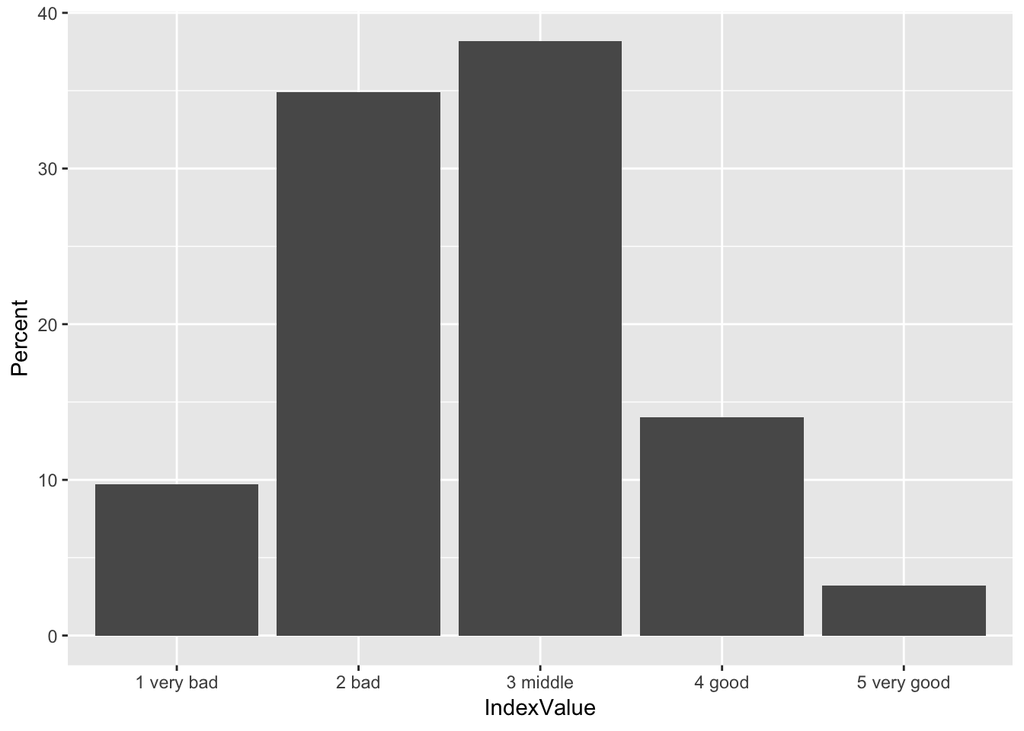

```r
base=ggplot(data = plotTable,
            aes(x = IndexValue,
                y = Percent))

plot1= base + geom_bar(stat = "identity")

plot1
```

You can the add more elements:

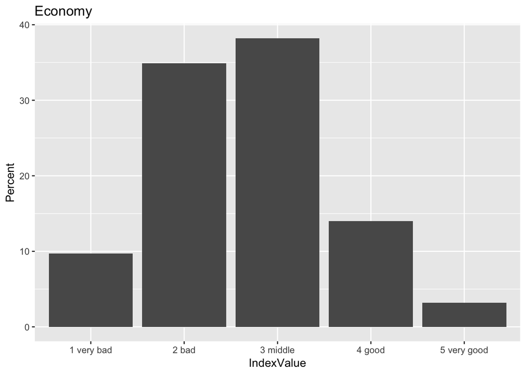

```r
# title
plot2 = plot1 + labs(title="Economy")
plot2
```

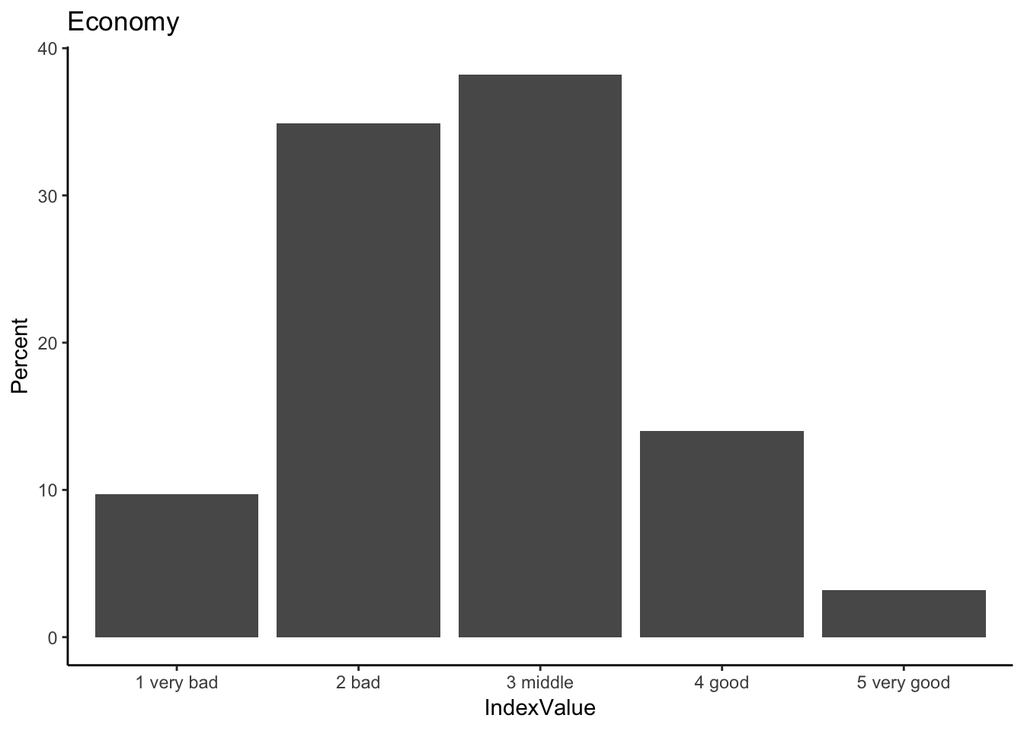

```r
# less ink
plot3 = plot2 + theme_classic()
plot3
```

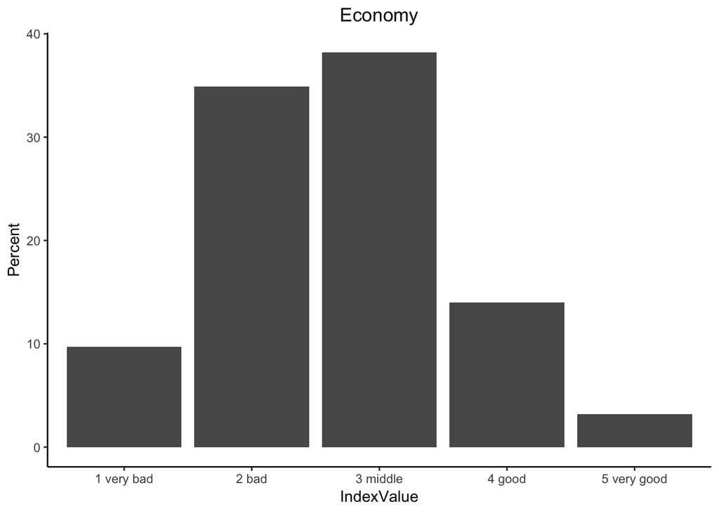

```r
# change default title position
plot3 + theme(plot.title = element_text(hjust = 0.5))
```

The numeric variable *gdp* can also be plotted, but since it is a numeric variable, we should use different plots:

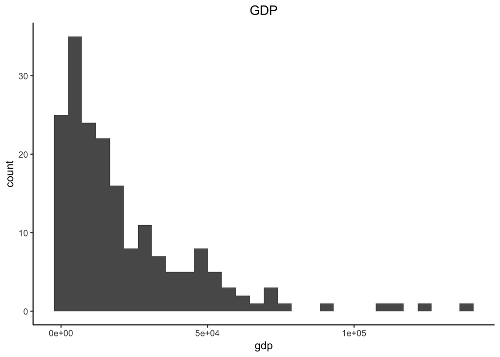

```r
# numeric variable do not need frequency table:

base=ggplot(data = worldidx,
            aes(x = gdp))
plot1= base + geom_histogram()

plot2= plot1 + labs(title="GDP") + theme_classic()

plot2 + theme(plot.title = element_text(hjust = 0.5))
```

A boxplot can also be a good choice:

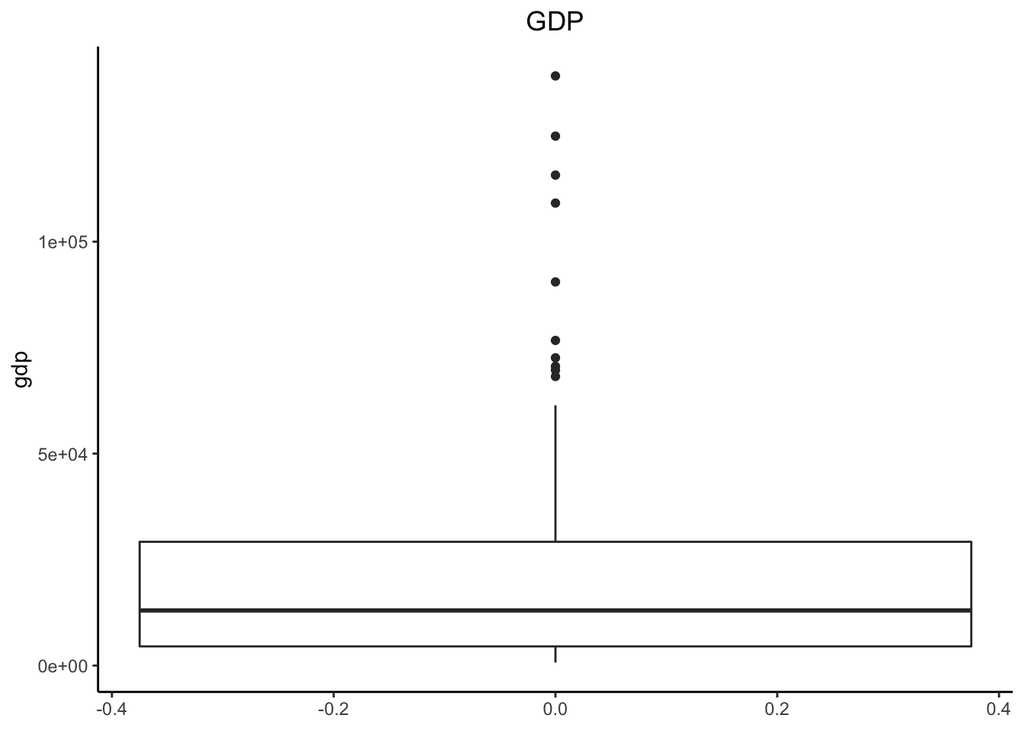

```r
base=ggplot(data = worldidx,
            aes(y=gdp))
plot1= base + geom_boxplot() + labs(title="GDP") + theme_classic()

plot2 = plot1 + theme(plot.title = element_text(hjust = 0.5))

plot2
```

Better x-axis:

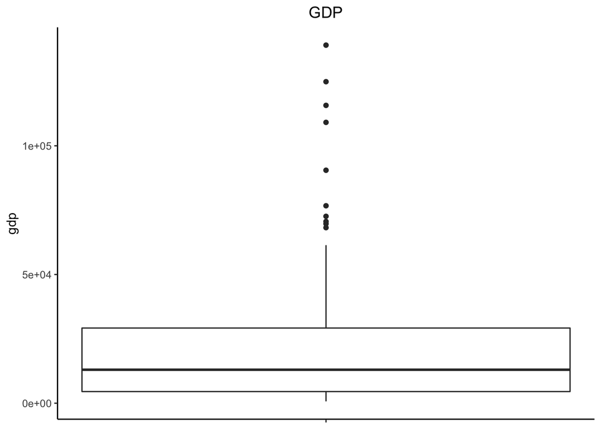

```r
plot3 = plot2 + scale_x_continuous(labels = NULL,breaks = 0 )

plot3
```

Avoid scientific notation:

```r
library(scales)
```

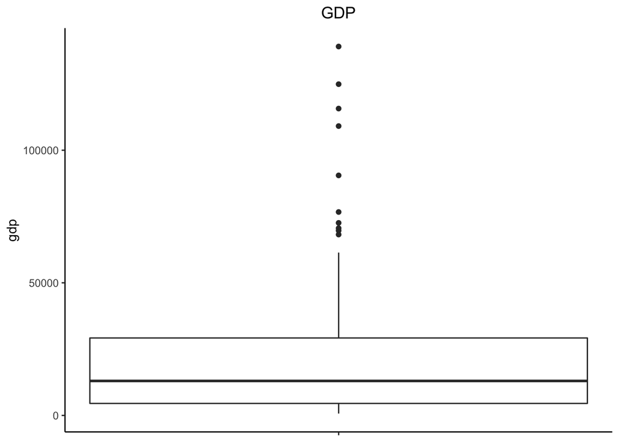

```r
plot3 + scale_y_continuous(labels = scales::number_format(big.mark = ""))
```

We can also explore bivariate relationships related to a explanatory model. Let’s explore the possible effect on these indexes on the gdp.

```r
corrDem=cor(x=worldidx[,c(3:6)],
            y=worldidx[,2],
            use = "na.or.complete",
            method = "spearman")
corrDem
```

```
##                             [,1]
## FreedomintheWorld      0.3675636
## IndexofEconomicFreedom 0.6556710
## PressFreedomIndex      0.3510658
## DemocracyIndex         0.4804244
```

```r
c(1,3:6, 10, 20:25,31)
```

```
##  [1]  1  3  4  5  6 10 20 21 22 23 24 25 31
```

And among the indexes:

```r
corrTable=round(cor(worldidx[,c(3:6)],
               use = "na.or.complete"),2)

# hide redundancy
corrTable[upper.tri(corrTable)]<-""
as.data.frame(corrTable)
```

```
##                        FreedomintheWorld IndexofEconomicFreedom
## FreedomintheWorld                      1
## IndexofEconomicFreedom              0.48                      1
## PressFreedomIndex                   0.83                   0.52
## DemocracyIndex                      0.89                   0.58
##                        PressFreedomIndex DemocracyIndex
## FreedomintheWorld
## IndexofEconomicFreedom
## PressFreedomIndex                      1
## DemocracyIndex                      0.76              1
```

We could explore the indexes by reducing their dimensionality. We will use a map for this case.

```r
library(rgdal)
```

```r
folder='world_map'
file='world_map.shp'
mapFile=file.path(folder,file)
mapWorld = rgdal::readOGR(mapFile,stringsAsFactors=F)
```

Do we have the map:

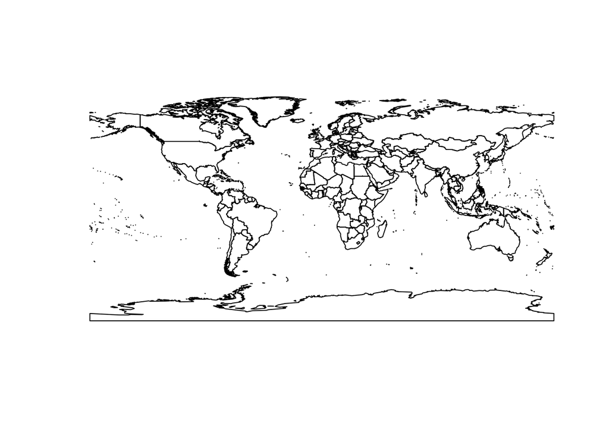

```r
plot(mapWorld)
```

The plan is to color the countries according to a group, which will result from clustering.

```r
# see data in map
head(mapWorld@data)
```

```
##   FIPS ISO2 ISO3 UN                NAME   AREA  POP2005 REGION SUBREGION
## 0   AC   AG  ATG 28 Antigua and Barbuda     44    83039     19        29
## 1   AG   DZ  DZA 12             Algeria 238174 32854159      2        15
## 2   AJ   AZ  AZE 31          Azerbaijan   8260  8352021    142       145
## 3   AL   AL  ALB  8             Albania   2740  3153731    150        39
## 4   AM   AM  ARM 51             Armenia   2820  3017661    142       145
## 5   AO   AO  AGO 24              Angola 124670 16095214      2        17
##       LON     LAT
## 0 -61.783  17.078
## 1   2.632  28.163
## 2  47.395  40.430
## 3  20.068  41.143
## 4  44.563  40.534
## 5  17.544 -12.296
```

Let’s add our data to the map data:

```r
mapWorldAll=merge(mapWorld, #map first
                   worldidx,
                   by.x='NAME', # common column
                   by.y='Country', # common column
                   all.x=F) # reduced map.
```

Now, let’s compute the clusters:

```r
head(mapWorldAll@data[,c(13:16)])
```

```
##    FreedomintheWorld IndexofEconomicFreedom PressFreedomIndex
## 6                  5                      3                 4
## 3                  1                      1                 2
## 11                 1                      3                 1
## 2                  3                      3                 3
## 8                  3                      3                 3
## 5                  1                      1                 2
##    DemocracyIndex
## 6               4
## 3               1
## 11              1
## 2               2
## 8               2
## 5               1
```

```r
# data for clustering
dataCluster=mapWorldAll@data[,c(13:16)]
```

```r
# setting the data as ordinal
dataCluster=as.data.frame(lapply(dataCluster,as.ordered))
```

```r
# calling library

library(cluster)
set.seed(123)

# computing distance matrix for ordinals
#dist=daisy(dataCluster,metric = "gower")

# computing clusters
result <- kmeans(dataCluster, centers = 3)

# adding the cluster
mapWorldAll$cluster=result$cluster
```

Let’s check the values:

```r
aggregate(IndexofEconomicFreedom~cluster,
          data=mapWorldAll,
          FUN=median,
          na.rm=T)
```

```
##   cluster IndexofEconomicFreedom
## 1       1                      2
## 2       2                      3
## 3       3                      3
```

If needed:

```r
#library(car)
#mapWorldAll$cluster<-recode(mapWorldAll$cluster,
#                             "3=1;2=3;1=2")
```

Now paint the world:

[figure not shown]

```r
# what:
varToPlot=mapWorldAll$cluster

#which colors:
palette = c('green','orange','red')

# plotting:

## base layer
plot(mapWorld,col='grey',border=0)

## top layer
plot(mapWorldAll, col = palette[varToPlot],border=F,add=T)


legend('left', legend = c("TOP","MEDIUM","LOW"),
       fill = palette,
       cex = 0.6,
       bty = "n",
       title="Clusters")
```

Finally, we could compute the hipotesized regression:

```r
LinReg = lm(gdp ~ ., data = worldidx[,c(2:6)])
summary(LinReg)
```

```
##
## Call:
## lm(formula = gdp ~ ., data = worldidx[, c(2:6)])
##
## Residuals:
##    Min     1Q Median     3Q    Max
## -28034 -12005  -3782   6375 113275
##
## Coefficients:
##                        Estimate Std. Error t value Pr(>|t|)
## (Intercept)              -18068       4764  -3.793 0.000203 ***
## FreedomintheWorld         -5506       2306  -2.388 0.017981 *
## IndexofEconomicFreedom    13575       1911   7.104 2.68e-11 ***
## PressFreedomIndex          3571       2314   1.543 0.124564
## DemocracyIndex             4103       2370   1.732 0.085039 .
## ---
## Signif. codes:  0 '***' 0.001 '**' 0.01 '*' 0.05 '.' 0.1 ' ' 1
##
## Residual standard error: 19320 on 181 degrees of freedom
## Multiple R-squared:  0.366,  Adjusted R-squared:  0.3519
## F-statistic: 26.12 on 4 and 181 DF,  p-value: < 2.2e-16
```

```r
library(xtable)
library(knitr)
kable(xtable(summary(LinReg)),type='html')
```

|  | Estimate | Std. Error | t value | Pr(>\|t\|) |
| --- | --- | --- | --- | --- |
| (Intercept) | -18067.696 | 4763.864 | -3.792656 | 0.0002030 |
| FreedomintheWorld | -5505.874 | 2305.879 | -2.387755 | 0.0179812 |
| IndexofEconomicFreedom | 13575.005 | 1910.907 | 7.103961 | 0.0000000 |
| PressFreedomIndex | 3570.992 | 2314.236 | 1.543054 | 0.1245641 |
| DemocracyIndex | 4103.246 | 2369.556 | 1.731652 | 0.0850394 |

Go to section beginning